# Analisis descriptivo e inferencial sobre los ingresos de los Colombianos

Anthony J. Servita R.

16/10/2020

importacion de librarias usadas para la resolucion del analisis estadistico

1.- conocimiento de problema: La base de datos suministrada (Base 10) contiene los ingresos en miles de pesos de vendedores informales en cuatro localidades: A, B, C, D.

Se estima, que el comportamiento comercial de las localidades es similar, por lo que se debe decidir cual de las cuatro localidades genera mejores ingresos o si no hay diferencias entre ellos.

Estos registros fueron tomados de forma aleatoria en cada una de las localidades presentadas anteriormente.

Para tomar la decicion se realizaran una serie de analisis estadistico como se presenta a continuacion: 1. Analisis descriptivo previo.

[output not shown]

```r
Ingresos <- read_excel("Base 10 .xltx")
```

```
## * `` -> ...1
```

```r
head(Ingresos)
```

```
## # A tibble: 6 x 3
##    ...1 Cuanti Cuali
##   <dbl>  <dbl> <chr>
## 1     1  9730. A
## 2     2  9902. A
## 3     3  7025  A
## 4     4  8545  A
## 5     5  6272. A
## 6     6  8738  A
```

Los ingresos se detectan como tipo de datos dbl, lo cual podriamos simplificar de manera que se pueda trabajar con valores enteros.

```r
df <- Ingresos
glimpse(df)
```

```
## Rows: 48
## Columns: 3
## $ ...1   <dbl> 1, 2, 3, 4, 5, 6, 7, 8, 9, 10, 11, 12, 13, 14, 15, 16, 17, 1...
## $ Cuanti <dbl> 9730, 9902, 7025, 8545, 6272, 8738, 11183, 10560, 8771, 1097...
## $ Cuali  <chr> "A", "A", "A", "A", "A", "A", "A", "A", "A", "A", "A", "A", ...
```

vemos que nuestra base de datos contiene 48 filas y 3 columnas en la que se 3 variables: …1: que contiene numero de vendedores Cuanti: los ingresos en miles de pesos Cuali: localidades.

Para continuar es necesario transformar las variables …1 y Cuanti pues ambas son dbl. Las llevaremos de dbl -> int

La variable Cuali se cambiara a factor

```r
df <- df %>%
  mutate(...1 = as.integer(...1)) %>%
  mutate(Cuanti = as.integer(Cuanti)) %>%
  mutate(Cuali = as.factor(Cuali))

glimpse(df)
```

```
## Rows: 48
## Columns: 3
## $ ...1   <int> 1, 2, 3, 4, 5, 6, 7, 8, 9, 10, 11, 12, 13, 14, 15, 16, 17, 1...
## $ Cuanti <int> 9729, 9901, 7025, 8545, 6271, 8738, 11183, 10560, 8771, 1097...
## $ Cuali  <fct> A, A, A, A, A, A, A, A, A, A, A, A, A, A, A, B, B, B, B, B, ...
```

revisaremos los niveles de la variable Cuali

```r
factor(df$Cuali)
```

```
##  [1] A A A A A A A A A A A A A A A B B B B B B B B B B B B B B B C C C C C C C C
## [39] C C D D D D D D D D
## Levels: A B C D
```

se observa un total de cuatrp niveles, lo que significa que existen 4 localidades distintas en nuestro dataframe.

Le cambiaremos el el nombre de la variable …1 por “sujeto” la variable Cuanti por “Ingresos” la variable Cuali por “Localidad”

De esta manera identificaremos con mejor facilidad nuestras columnas

```r
nameVar <- c("Sujeto", "Ingresos", "Localidad")
colnames(df) <- nameVar
head(df)
```

```
## # A tibble: 6 x 3
##   Sujeto Ingresos Localidad
##    <int>    <int> <fct>
## 1      1     9729 A
## 2      2     9901 A
## 3      3     7025 A
## 4      4     8545 A
## 5      5     6271 A
## 6      6     8738 A
```

realizremos un conocimiento descriptivo de los datos.

```r
skim(df)
```

Data summary

| Name | df |
| --- | --- |
| Number of rows | 48 |
| Number of columns | 3 |
| _______________________ |  |
| Column type frequency: |  |
| factor | 1 |
| numeric | 2 |
| ________________________ |  |
| Group variables | None |

**Variable type: factor**

| skim_variable | n_missing | complete_rate | ordered | n_unique | top_counts |
| --- | --- | --- | --- | --- | --- |
| Localidad | 0 | 1 | FALSE | 4 | A: 15, B: 15, C: 10, D: 8 |

**Variable type: numeric**

| skim_variable | n_missing | complete_rate | mean | sd | p0 | p25 | p50 | p75 | p100 | hist |
| --- | --- | --- | --- | --- | --- | --- | --- | --- | --- | --- |
| Sujeto | 0 | 1 | 24.50 | 14.00 | 1 | 12.75 | 24.5 | 36.25 | 48 | ▇▇▇▇▇ |
| Ingresos | 0 | 1 | 6888.29 | 2717.59 | 2052 | 3895.50 | 7445.0 | 8756.00 | 11183 | ▇▂▆▇▅ |

Podemos observar que la variable “Localidad” se encuentra representada por 4 localidades de las cuales 15 pertenecen a “A”, otras 15 pertenecen a “B”, 10 pertencen a “C” y pertenecen a “D”.

Nuestra variable “Ingresos” se encuentra con un promedio de 6888 pesos en ingresos con una desviacion estandar de 2718. el ingreso mas bajo esta representado por el percentil 0, el cual tiene un valor de 2052 pesos, el 50% de los ingresos son de 7445 pesos sobre esta muestra y el maximo ingreso se encuentra en el valor del percentil 100 el cual es de 11183 pesos.

El histograma refleja que los datos de la variable “Ingresos” no contiene una distribucion normal, ademas de reflejar una asimetria hacia la izquierda.

Realizaremos unos histogramas sobre la variable “ingresos” para visualizarlo con mayor detalle.

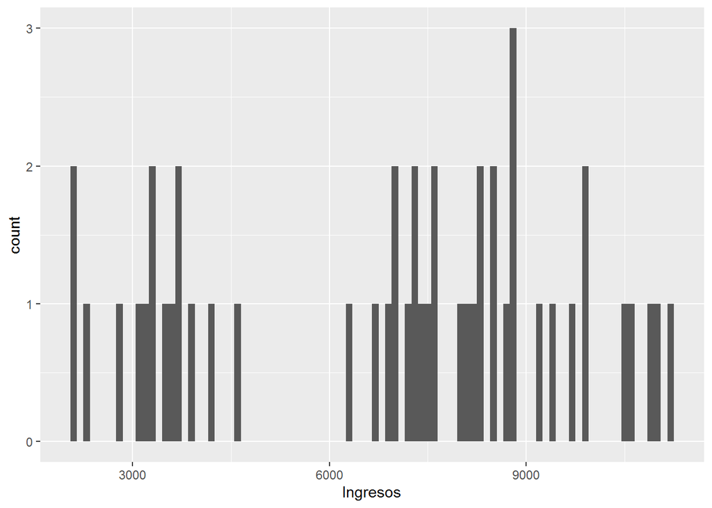

```r
ggplot(df, aes(Ingresos)) + geom_histogram(binwidth = 100)
```

como podemos visualizar, la variable Ingresos no tiene forma de distribucion normal. La asimetria de los datos no es tan clara, por lo que no sabremos si realmente es asimetrica hacia la izquierda.

analizaremos los datos por medio de un boxplot o grafico de caja

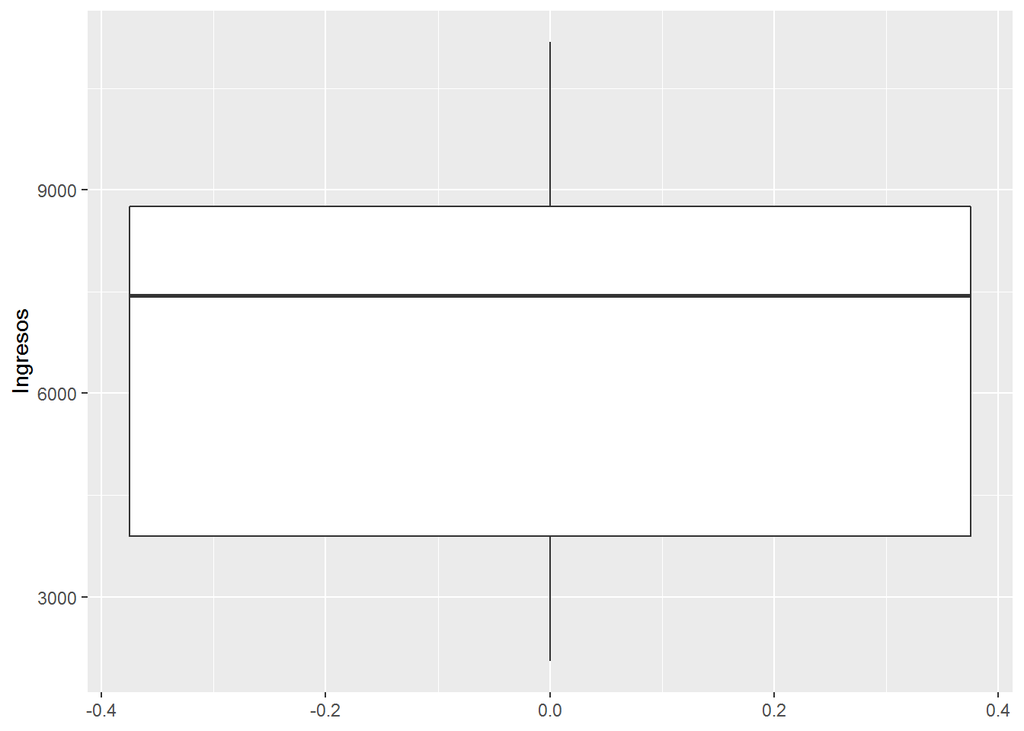

```r
ggplot(df, aes(y = Ingresos)) + geom_boxplot()
```

Como vemos, la mediana se encuentra cerca del valor del tercer cuartil y bastante alejado del primer cuartil. asi mismo, el rango intercuartilico es bastante grande, por lo que podemos inferir que se encuentran gran cantidad de los datos entre el 25% y 75%. No encontramos valores atipicos en la grafica.

realizaremos la misma grafica para los 4 elementos de la variable “Localidad”

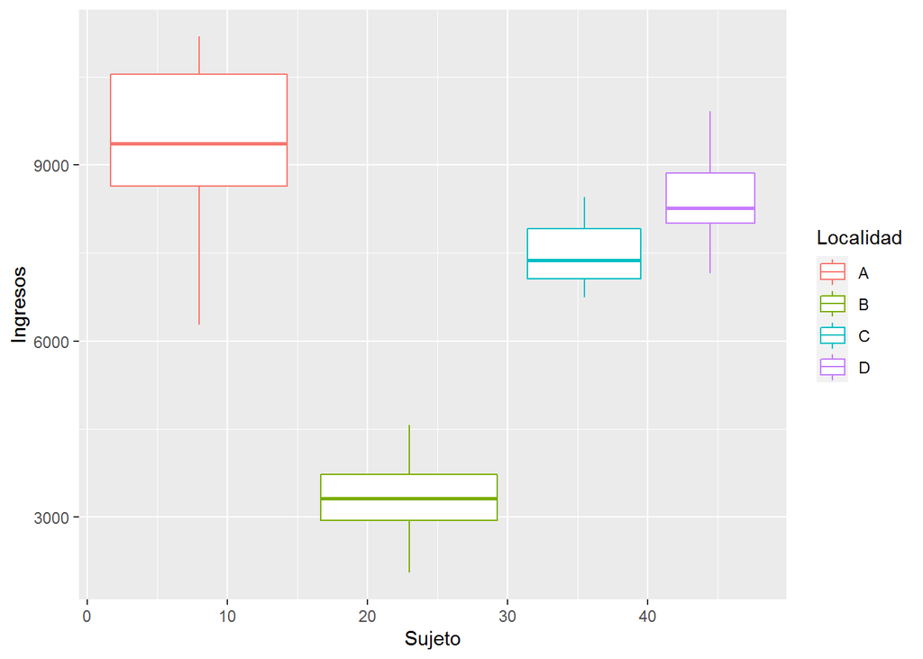

```r
ggplot(df, aes(x = Sujeto, y = Ingresos, color = Localidad)) +
  geom_boxplot()
```

se observa que los valores mas altos se encuantran en las localidad A, D y C respecitvamente; mientras que los valores mas bajos en los sujetos de la localidad B.

4.- analisis exploratorio de varible (EDA)

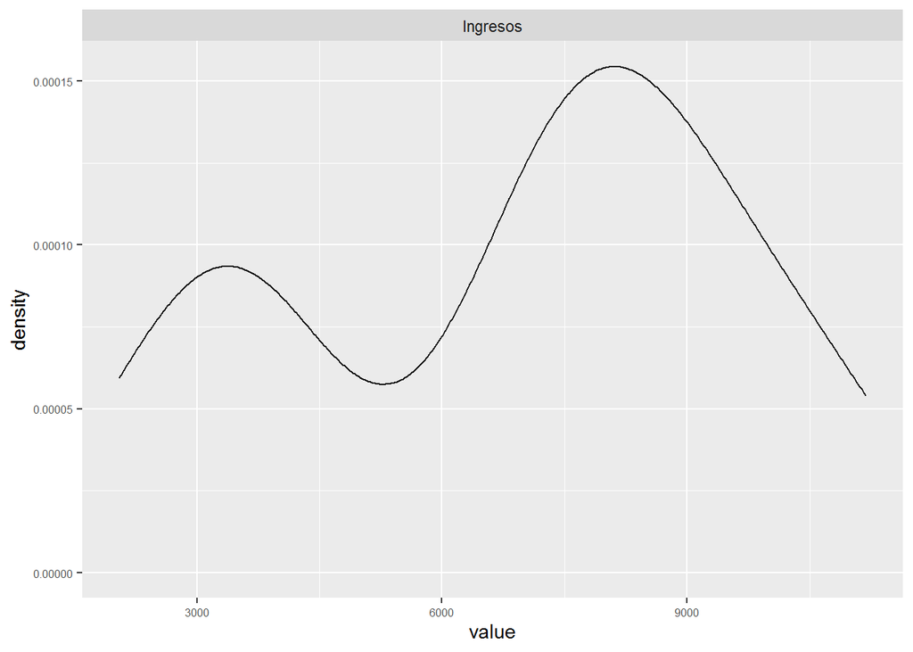

```r
df %>%
  select(Ingresos) %>%
  gather() %>%
  ggplot(aes(value)) +
  geom_density() +
  facet_wrap(~key, scale = 'free') +
  theme(axis.text = element_text(size = 6))
```

Calcularemos la moda para observa este valor con mayor detalle.

```r
mfv(df$Ingresos)
```

```
## [1] 9729
```

5.- tablas de frecuencias para la variable “Ingresos” y “Localidad”

```r
freqIng <- fdt(df[, 2], breaks = "Sturges")
freqIng
```

```
## Ingresos
##           Class limits  f   rf rf(%) cf  cf(%)
##    [2031.48,3354.8157)  8 0.17 16.67  8  16.67
##  [3354.8157,4678.1514)  7 0.15 14.58 15  31.25
##  [4678.1514,6001.4871)  0 0.00  0.00 15  31.25
##  [6001.4871,7324.8229)  7 0.15 14.58 22  45.83
##  [7324.8229,8648.1586) 12 0.25 25.00 34  70.83
##  [8648.1586,9971.4943)  9 0.19 18.75 43  89.58
##   [9971.4943,11294.83)  5 0.10 10.42 48 100.00
```

tabla muestra las frecuencias absolutas (f), relativas (rf) y acumuladas (cf) de la variable “Ingresos”. vemos que el 25% de los ingresos se encuentran entre los 7324.82 y los 8648.16 pesos. los ingresos mas altos estan repesentados por un 10% de los datos y los mas bajos representan el 17% de los ingresos.

realizaremos un test de shapiro-wilk para medir la distribucion de los datos.

```r
shapiro.test(df$Ingresos)
```

```
##
##  Shapiro-Wilk normality test
##
## data:  df$Ingresos
## W = 0.92251, p-value = 0.003648
```

Como el p-value es menor a 0.05 (valos alfa de significancia); se tiene un 95% de confianza de que la variable “Ingresos” no se distribuye normalmente.

Realizeremos una prueba de hipotesis para la igualdad de medias entre las 4 localidades

Primero separaremos la variable en 4 partes las cuales estara asignadas por las cuatros localidades

```r
Localidad_A <- df %>%
  select(Ingresos, Localidad) %>%
  filter(Localidad == "A")

Localidad_B <- df %>%
  select(Ingresos, Localidad) %>%
  filter(Localidad == "B")

Localidad_C <- df %>%
  select(Ingresos, Localidad) %>%
  filter(Localidad == "C")

Localidad_D <- df %>%
  select(Ingresos, Localidad) %>%
  filter(Localidad == "D")
```

Hipotesis: H: Todas las medias son iguales. H1: Al menos una de las medias es diferente. nivel de significancia alfa de 0.05

Verificamos las condiciones para realizar un analisis ANOVA

Prueba de normalidad sobre las 4 localidades

```r
## LOcalidad A
shapiro.test(Localidad_A$Ingresos)
```

```
##
##  Shapiro-Wilk normality test
##
## data:  Localidad_A$Ingresos
## W = 0.94046, p-value = 0.3882
```

Como el valor-p en mayor al 0.05 (valor de significancia) tendremos un 95% de confianza de que los datos en la localidad A se distribuyen normalmente.

```r
## Localidad B
shapiro.test(Localidad_B$Ingresos)
```

```
##
##  Shapiro-Wilk normality test
##
## data:  Localidad_B$Ingresos
## W = 0.95915, p-value = 0.6776
```

Como el valor-p en mayor al 0.05 (valor de significancia) tendremos un 95% de confianza de que los datos en la localidad B se distribuyen normalmente.

```r
## Localidad C
shapiro.test(Localidad_C$Ingresos)
```

```
##
##  Shapiro-Wilk normality test
##
## data:  Localidad_C$Ingresos
## W = 0.93443, p-value = 0.4928
```

Como el valor-p en mayor al 0.05 (valor de significancia) tendremos un 95% de confianza de que los datos en la localidad C se distribuyen normalmente.

```r
## Localidad D
shapiro.test(Localidad_D$Ingresos)
```

```
##
##  Shapiro-Wilk normality test
##
## data:  Localidad_D$Ingresos
## W = 0.97782, p-value = 0.9513
```

Como el valor-p en mayor al 0.05 (valor de significancia) tendremos un 95% de confianza de que los datos en la localidad D se distribuyen normalmente.

Asi, tenemos que los ingresos de las cuatro localidades se distribuyen normalmente.

Varianza constante entre grupos:

```r
fligner.test(Ingresos ~ Localidad , df)
```

```
##
##  Fligner-Killeen test of homogeneity of variances
##
## data:  Ingresos by Localidad
## Fligner-Killeen:med chi-squared = 9.2953, df = 3, p-value = 0.02561
```

Dado que el valor-p 0.03 se encuentra por debajo del valor de significancia 0.05, tenemos un 95% de confianza de que no hay evidencia de homocedasticidad.

Analisis anova:

```r
anova <- aov(Ingresos ~ Localidad, df)
summary(anova)
```

```
##             Df    Sum Sq  Mean Sq F value Pr(>F)
## Localidad    3 299715120 99905040   92.75 <2e-16 ***
## Residuals   44  47392554  1077104
## ---
## Signif. codes:  0 '***' 0.001 '**' 0.01 '*' 0.05 '.' 0.1 ' ' 1
```

Conlusiones del ANOVA: dado que el valor-p es menor al valor 0.05 siendo este significativo. tendremos un 95% de confianza de rechazar la hipotesis nula. Por lo tanto, debemos considerar que al menos una de las medias es diferente de las demas.

Prueba de Mann Whitney para la hipotesis: H0: P(X > Y) = P(Y > X) H1: P(X > Y) != P(Y > X)

Analisis de homocedasticidad entre los ingresos de las localidades A y C

```r
fligner.test(x = list(Localidad_A$Ingresos,Localidad_C$Ingresos))
```

```
##
##  Fligner-Killeen test of homogeneity of variances
##
## data:  list(Localidad_A$Ingresos, Localidad_C$Ingresos)
## Fligner-Killeen:med chi-squared = 5.3504, df = 1, p-value = 0.02072
```

no hay evidencia significativa de la existencia de homocedasticidad.

dado que no hay varianzas iguales entre los ingresos de la localiad A y la localidad C no se podra realizar el test de Mann Whitney. a pesar de que estas variables cumplen con las condiciones de normalidad e independencia.

Conclusiones de analisis descriptivo: Debido a que las varianzas son disitintas entre si, y sus promedios son distintos… podemos concluir que existe diferencia entre los ingresos de vendedores en las 4 localidades “A”, “B”, “C”, “D”.